# Presentation 10: Trophic Level

Somali Fish Stock Training

Mwijage

TAFIRI

2025-12-15

## Welcome to Presentation 10

**Trophic Level: Understanding the Marine Food Web**

### Learning Objectives

- Define what a trophic level is.
- Understand its importance in fisheries management.
- Learn about “fishing down the food web.”
- Calculate the Mean Trophic Index of the catch.

### Why This Matters

- Provides an ecosystem-level view of fishing impacts.
- A key indicator for Ecosystem-Based Fisheries Management (EBFM).
- Helps detect long-term changes in the marine environment.

## What is a Trophic Level?

A trophic level is the position an organism occupies in a food chain. It represents a “step” in the flow of energy.

- **Level 1**: **Primary Producers** (e.g., Phytoplankton) - Create their own food.
- **Level 2**: **Primary Consumers** (Herbivores, e.g., Zooplankton) - Eat producers.
- **Level 3**: **Secondary Consumers** (Carnivores, e.g., Mackerel) - Eat primary consumers.
- **Level 4**: **Tertiary Consumers** (Carnivores, e.g., Tuna) - Eat secondary consumers.
- **Level 5**: **Apex Predators** (e.g., large Sharks) - Top of the food chain.

## The Marine Food Web

In reality, it’s a complex web, not a simple chain. A single species can feed at multiple trophic levels.

[figure not shown]

*Source: Arreguín-Sánchez (2014)*

## Why is Trophic Level Important?

1. **Ecosystem Health Indicator**: The average trophic level of the catch can signal major shifts in the ecosystem.
2. **“Fishing Down the Food Web”**: This is a classic sign of overfishing. Fisheries first deplete large, high-trophic-level predators and then shift to targeting smaller, lower-trophic-level species.
3. **Management Strategy**: High-trophic-level species (like sharks) are often long-lived and slow to reproduce, requiring more conservative management than low-trophic-level species (like sardines).

## Calculating Mean Trophic Index (MTI) of the Catch

We can estimate the health of the fishery by tracking the average trophic level of the fish we catch over time.

**Step 1: Assign Trophic Levels to Fish Groups**

We use known values from sources like FishBase.

```r
trophic_levels <- tibble::tribble(
  ~fish_group,       ~trophic_level,
  "Tuna",            4.4,
  "Shark",           4.5,
  "Billfish",        4.5,
  "Jacks",           3.9,
  "Mackerel",        3.6,
  "Rays and Skates", 3.5,
  "Other",           3.7  # Average assumption
)
```

## Calculating MTI of the Catch (cont.)

```r
mti_by_year <- lw |>
  filter(!is.na(fish_group)) |>
  left_join(trophic_levels, by = "fish_group") |>
  group_by(year) |>
  summarise(
    mti = mean(trophic_level, na.rm = TRUE),
    .groups = 'drop'
  )
```

**Step 3: Visualize the trend.**

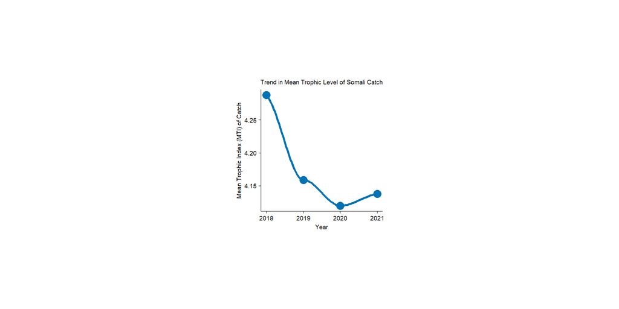

## Key Takeaways

- Trophic level is a fundamental concept for understanding an organism’s role in the ecosystem.
- Tracking the **Mean Trophic Index (MTI)** of the catch is a powerful, simple indicator of ecosystem health.
- A declining MTI is a classic sign of **“fishing down the food web,”** indicating unsustainable pressure on top predators.
- This analysis is a core component of **Ecosystem-Based Fisheries Management (EBFM)**.

## Questions & Discussion

**Thank You**